# popbio

08 de mayo de 2019

## Contenido

- popbio
- Practica con popbio
- Tarea 05 instrucciones
- Metas de trabajo grupal
- Metas para la próxima semana

## R y paquetes de R

Los paquetes se crean por un procedimiento normalizado. La documentación es parte importante de dicho proceso.

- Todo paquete viene con un manual de funciones.
- Ahora se promueve que venga con un manual de uso, que explica el contexto en que se usa el paquete, el tipo de datos que procesa, y cómo combinar sus funciones de manera efectiva.
- R es uno de los lenguajes más populares (si no el más popular) entre profesionales de las ciencias naturales (especialmente de la vida y la tierra).
- R tiene un grupo activo que lo mantiene. También está en constante desarrollo y tiene una comunidad de entusiastas que ayudan a quienes están empezando a utilizarle.
- Muchos programas de análisis de datos de ecología se encontraban dispersos, y ahora han sido compilados en paquetes dentro de R.

## popbio

Es un paquete de R. Tiene buena documentación introductoria:

Stubben, C., & Milligan, B. (2007). Estimating and analyzing demographic models. Journal Of Statistical Software, 22(11), 1–23. https://doi.org/10.18637/jss.v022.i11

- Asume que existen buenos datos.
- Basado en paquete de MatLab

## ¿Qué hace?

- Proyección de matrices
- Cálculo de parámetros como \(R_0\), y \(T_c\)
- Proyección estocástica de matrices
- Análisis de viabilidad poblacional sencillos

```
demo("stage.classify")
demo("fillmore")
```

Incluye conjunto de datos de práctica.

## Proyección de matrices

- `pop.projection(TM,n0,t)`: Proyecta una población.
  - `TM`: matriz de transición; `n0`: vector de tamaño de población inicial;- `t`: cantidad de tiempo que se desea proyectar.

  Devuelve valores como
  - `$lambda`: \(\lambda\),
  - `$stable.stage`: la proporción estable de clases de edad, o etapas, en una población;
  - `$stage.vectors`: la cantidad de individuos en cada clase de edad o etapa, desde el tiempo cero hasta el tiempo `t`;
  - `$pop.sizes`: vector con el tamaño de la población total, desde el tiempo cero hasta el tiempo `t`;
  - `$pop.changes`: el \(\lambda\) desde el tiempo cero hasta el tiempo `t`.
- `stage.vector.plot(stage.vectors, col)`: grafica la matriz de transición con respecto al tiempo. `stage.vectors`: recibe la salida de la función `pop.projection`, específicamente el vector: `$stage.vectors`. El argumento `col` es una secuencia de enteros, con las columnas que se desean graficar.

## Parámetros poblacionales

- `fundamental.matrix(TM)`: Recibe una matriz de transición y devuelve una matriz fundamental, con los errores de estimación.
- La matriz fundamental tiene la misma estructura que una matriz de transición, pero sus elementos contienen el número de unidades de tiempo que pasa cada individuo en una *etapa* de crecimiento. Es apropiada para poblaciones con crecimiento estructurado por etapas.
- `net.reproductive.rate(TM)`: Devuelve el \(R_0\) de una matriz de transición.
- `generation.time(TM)`: Devuelve el \(T_c\) de una matriz de transición.

## Proyecciones estocásticas

`stoch.projection(matrices,n0,tmax,nreps,...)`: Genera una proyección estocástica de una población.

`stoch.growth.rate(matrices)`: Versión estocástica para calcular *el logaritmo* de la tasa de crecimiento.

## Calcula la probabilidad de cuasi-extinción

- `stoch.quasi.ext(matrices, n0, Nx, tmax, maxruns, nreps)`. Hace una proyección de la probabilidad de extinción de una población. Cuyos argumentos son:
  - `matrices`: Una lista con dos o más matrices de transición
  - `n0`: Vector con tamaño de población inicial.
  - `Nx`: Umbral de quasi-extinción.
  - `tmax`: número de pasos a proyectar en el futuro.
  - `maxruns`: Número de veces que se simula la distribución acumulativa sobre la probabilidad de extinción.
  - `nreps`: Número de iteraciones.

## Ejercicio

1. Grafique el tamaño poblacional de cada etapa contra el tiempo.
2. Grafique el tamaño poblacional contra el tiempo.

## Solución

```r
library(popbio)
stages <- c("seedling", "vegetative", "flowering")
A <- matrix(c(0, 0, 5.905, 0.368, 0.639, 0.025, 0.001, 0.152, 0.051), nrow = 3, byrow = TRUE, dimnames = list(stages, stages))
n <- c(5, 5, 5)
p <- pop.projection(A, n, 10)
p
```

```
## $lambda
## [1] 0.9812831
##
## $stable.stage
##   seedling vegetative  flowering
## 0.44717129 0.47682475 0.07600396
##
## $stage.vectors
##            0      1         2         3         4         5         6
## seedling   5 29.525  6.023100  5.112933 13.030853 10.841000  8.851612
## vegetative 5  5.160 14.187940 11.304241  9.160138 10.694580 10.860800
## flowering  5  1.020  0.865865  2.206749  1.835902  1.499003  1.712866
##                    7         8         9
## seedling   10.114475 10.316326  9.777111
## vegetative 10.240266 10.309333 10.425465
## flowering   1.747049  1.655734  1.661777
##
## $pop.sizes
##  [1] 15.00000 35.70500 21.07691 18.62392 24.02689 23.03458 21.42528
##  [8] 22.10179 22.28139 21.86435
##
## $pop.changes
## [1] 2.3803333 0.5903068 0.8836175 1.2901091 0.9587000 0.9301353 1.0315755
## [8] 1.0081262 0.9812831
```

## Solución

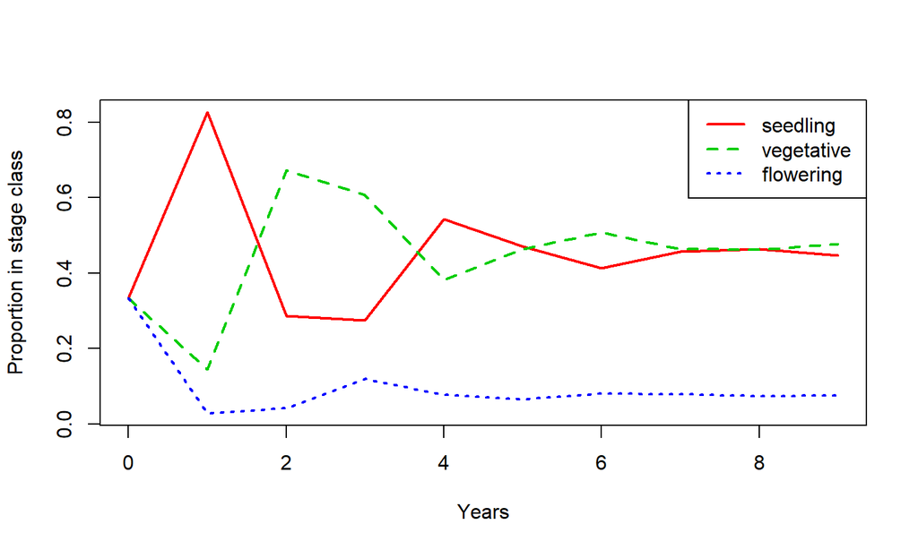

```r
stage.vector.plot(p$stage.vectors, col = 2:4)
```

## Ejercicio 2

¿Qué pasa si elimina la fecundidad de la matriz de transición anterior?

## Solución

```r
library(popbio)
stages <- c("seedling", "vegetative", "flowering")
A <- matrix(c(0, 0, 0, 0.368, 0.639, 0.025, 0.001, 0.152, 0.051), nrow = 3, byrow = TRUE, dimnames = list(stages, stages))
n <- c(5, 5, 5)
p <- pop.projection(A, n, 10)
p
```

[output not shown]

## Proyección estocástica

El método anterior es *determinístico*, es decir, dadas las condiciones iniciales, y la matriz de transición, el resultado siempre va a ser el mismo. Sin embargo, al incorporar todos los errores de observación y de proceso, existe incertidumbre sobre los argumentos del modelo y sobre su resultado final.

**Popbio** permite incorporar incertidumbre en las matrices de transición, aunque no en el vector del tamaño poblacional.

```r
data("hudsonia")
str(hudsonia)
```

```
## List of 4
##  $ A85: num [1:6, 1:6] 0.4995 0.0004 0 0 0 ...
##   ..- attr(*, "dimnames")=List of 2
##   .. ..$ : chr [1:6] "seed" "seedlings" "tiny" "small" ...
##   .. ..$ : chr [1:6] "seed" "seedlings" "tiny" "small" ...
##  $ A86: num [1:6, 1:6] 0.4995 0.0004 0 0 0 ...
##   ..- attr(*, "dimnames")=List of 2
##   .. ..$ : chr [1:6] "seed" "seedlings" "tiny" "small" ...
##   .. ..$ : chr [1:6] "seed" "seedlings" "tiny" "small" ...
##  $ A87: num [1:6, 1:6] 0.4995 0.0003 0 0 0 ...
##   ..- attr(*, "dimnames")=List of 2
##   .. ..$ : chr [1:6] "seed" "seedlings" "tiny" "small" ...
##   .. ..$ : chr [1:6] "seed" "seedlings" "tiny" "small" ...
##  $ A88: num [1:6, 1:6] 0.4995 0.0003 0 0 0 ...
##   ..- attr(*, "dimnames")=List of 2
##   .. ..$ : chr [1:6] "seed" "seedlings" "tiny" "small" ...
##   .. ..$ : chr [1:6] "seed" "seedlings" "tiny" "small" ...
```

## Proyección estocástica

```r
n <- c(4264, 3, 30, 16, 25, 5)
names(n) <- c("seed", "seedlings", "tiny", "small", "medium","large")

x.eq <-
  stoch.projection(
  matrices = hudsonia,
  n0 = n,
  tmax = 10,
  nreps = 1000,
  verbose = FALSE
  )

str(x.eq)
```

```
##  num [1:1000, 1:6] 1904 2315 3010 3142 2387 ...
##  - attr(*, "dimnames")=List of 2
##   ..$ : NULL
##   ..$ : chr [1:6] "seed" "seedlings" "tiny" "small" ...
```

## Representar gráficamente la proyección

1. Sumar filas
2. Hacer histograma

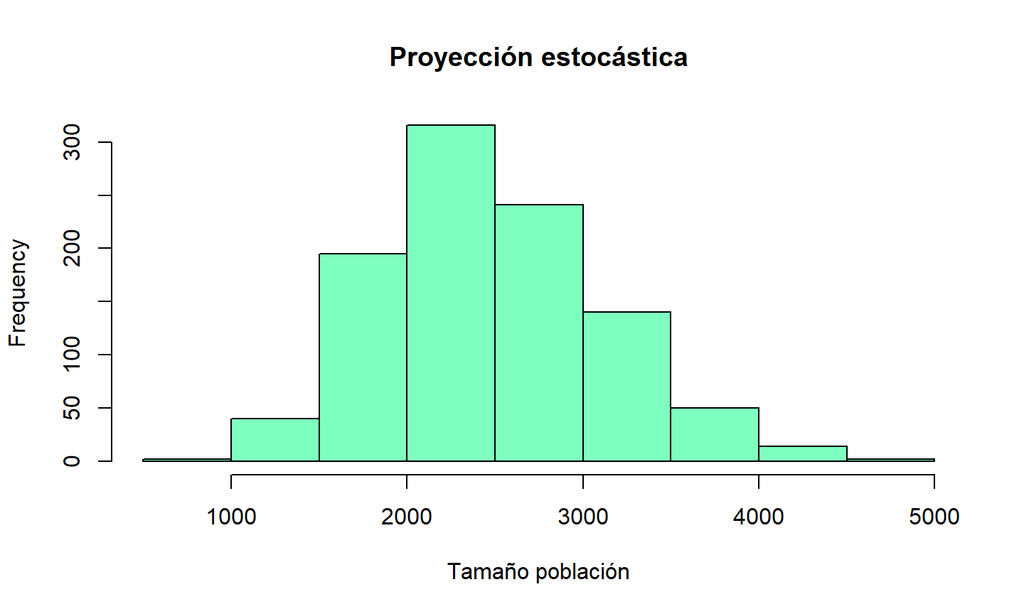

## Probabilidad de Cuasi-Extinción

Es una proyección estocástica, que analiza cuántas veces la población bajo de un umbral de cuasi-extinción.

```r
sqe <- stoch.quasi.ext(
  hudsonia,
  n,
  Nx = 10, #Umbral de cuasi-extinción
  nreps = 500,
  sumweight = c(0, 1, 1, 1, 1, 1), #Excluir etapa de análisis
  verbose = FALSE
  )

str(sqe)
```

```
##  num [1:50, 1:10] 0 0 0 0 0 0 0 0 0 0 ...
```

## Cuasi-extinción

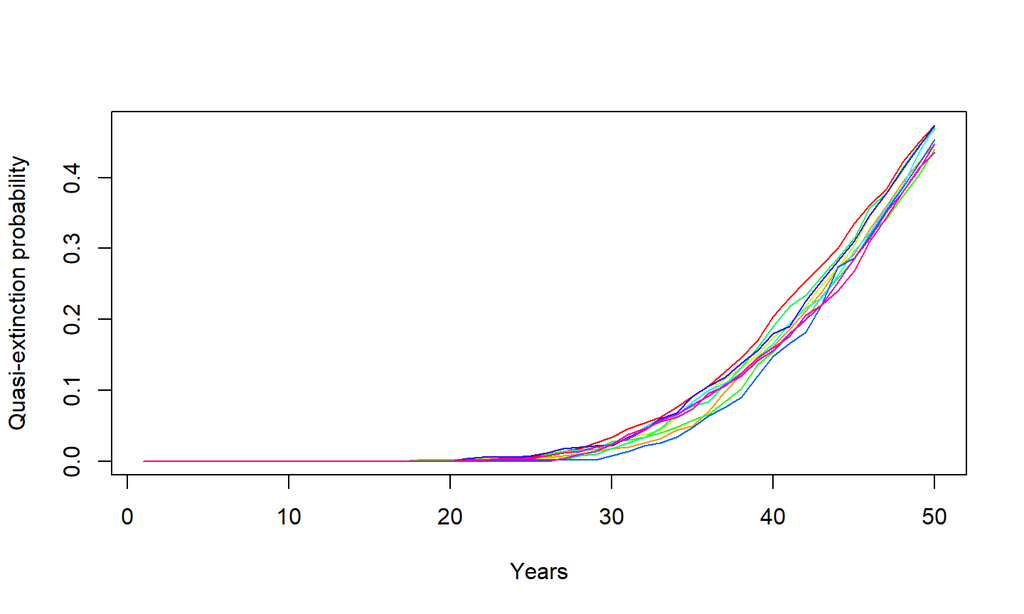

## Usando una clase de referencia

El documento `Source.R` en el repositorio del material del curso contiene facilidades para usar el paquete.

```r
library(popbio)
data(whale)
source("C:/localRepos/dinPob/Source.R")

whaleTM <- transMat$new(
    matriz=whale,
    n0 = c(100,80,60,40),
    t = 15
)
```

## Población en el tiempo

`transMat$plotTM()`

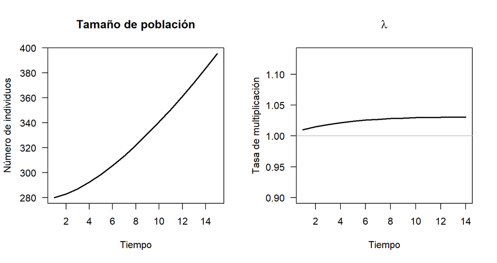

Resultados de la proyección de la matriz de transición

## Graficar etapas

`transMat$plotStage()`

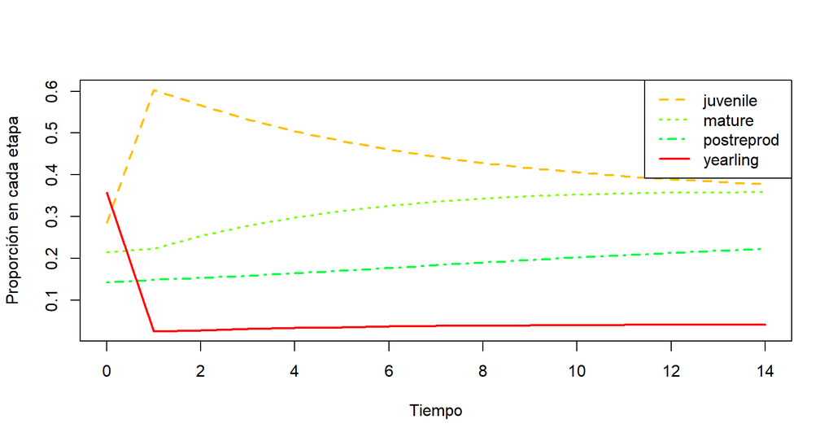

Proporción de la población en cada etapa de edad

## Otras funciones

```r
# La tasa de multiplicación
whaleTM$darLambda()
```

```
## [1] 1.030625
```

```r
#La tasa de crecimiento neto
whaleTM$darR0()
```

```
## [1] 2.013144
```

```r
#El tiempo de generación
whaleTM$darTc()
```

```
## [1] 27.85079
```

## Estocasticidad

clase de referencia `transStochMat`

```r
# hudsonia es una lista de matrices de transición
data("hudsonia")
n <- c(4264, 3, 30, 16, 25, 5)
names(n) <-
  c("seed", "seedlings", "tiny", "small", "medium", "large")


hudsoniaStoch <- transStochMat$new(
  matriz = hudsonia,
  n0 = n,
  t = 50,
  umbral = 10,# Número de plantas con potencial reproductivo.
  incluirEtapa = c(0,1,1,1,1,1)
)
```

## Tamaño de población

`hudsoniaStoch$plotN()`

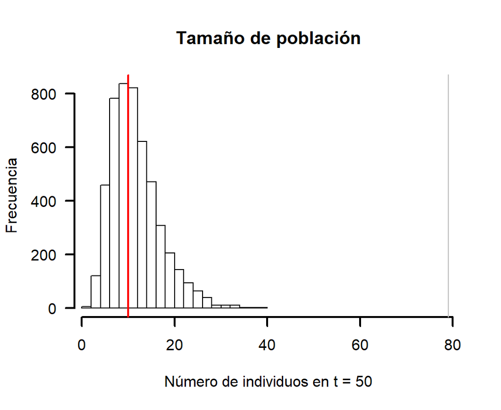

Población total de a 50 años

## Probabilidad de cuasi-extinción

`hudsoniaStoch$plotExtProb()`

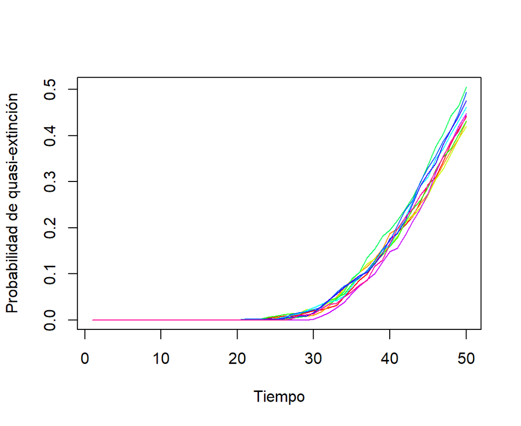

Probabilidad de extinción de a 50 años. Umbral de quasi-extición 10 individuos sobre tierra.

## Growth Rate

```r
# GR estocástico
hudsoniaStoch$darGR()
```

```
## [1] Calculating stochastic growth at time 1
## [1] Calculating stochastic growth at time 10000
## [1] Calculating stochastic growth at time 20000
## [1] Calculating stochastic growth at time 30000
## [1] Calculating stochastic growth at time 40000
## [1] Calculating stochastic growth at time 50000
```

```
## $approx
## [1] 0.9635547
##
## $sim
## [1] 0.9641735
##
## $simCI
## [1] 0.9636163 0.9647311
```

## Para la Tarea…

```r
hudsoniaStoch$extProb()
```

```
## [1] 0.4404
```

## Tarea 05 instrucciones

- Ver sección de asignaciones
- Descargar plantilla
- Plazo de entrega vence el 22 de mayo.
- Se reciben consultas en foro hasta el 20 de mayo.

## Avances del trabajo grupal

## Metas de trabajo grupal

- 15 Mayo: Revisión de Introducción, complementar revisión bibliográfica, mejora de redacción 7 %
- 22 Mayo: Metodología para la estimación de abundancia, Área de estudio, gestión de datos (incluir: planeamiento, colecta, control de calidad, descripción, integración, análisis). Datos almacenados en Base de Datos, y exportados a CSV 7 %.
- 5 de Junio: Análisis de datos con *unmarked*. Desarrollo de scriot de análisis, e integración de resultados en documento. 6 %
- 12 de Junio: Entrega de documento, con resultados.
- 19 de Junio: Defensa grupal de documento 5 %.